# Incidence plots

Michelle Coombe

## Load packages and data

```r
library(tidyverse)
library(lubridate)
library(incidence)
#library(RColorBrewer)
#library(viridis)
library(mgcv)
s.data <- read_csv("data/COVID-19_Singapore - singapore_ncov_2019_fix.csv")
t.data <- read_csv("Tianjin135casesFeb22.csv")
#Need to replace one date which is labelled as "none" with NA
t.data$symptom_onset[which(t.data$symptom_onset == "none")] <- NA
```

## Select variables of interest and clean for incidence plotting purposes

There are two possible choices of dates we can use to demonstrate the incidence curve of the epidemic: the date of symptom onset or the date of COVID-19 confirmation. The date of symptom onset is biologically more consistent (there is nothing about the nature of the virus that would mean each case would be confirmed on the same day post-infection); however, there is missing data for 10 cases (in both Tianjin and Singapore datasets). Therefore, I will make the curves using the date of symptom onset, but we could also run the same analysis using the date of confirmation instead as a sensitivity analysis to make sure it does not impact the results.

```r
### 1. Singapore dataset
head(s.data$date_onset_symptoms)
```

```
## [1] "20/01/2020" "21/01/2020" "23/01/2020" "23/01/2020" "24/01/2020"
## [6] "25/01/2020"
```

```r
sum(is.na(s.data$date_onset_symptoms)) #10
```

```
## [1] 10
```

```r
# Make a column for grouping, based on the reason why the case was exposed
# Turn 'presumed_reason' into lower case and get trim any whitespace so don't have issues with case sensitivity, etc
s.data$presumed_reason <- str_to_lower(s.data$presumed_reason)
s.data$presumed_reason <- str_trim(s.data$presumed_reason)
table(s.data$presumed_reason)
```

```
##
##                                                                   arrived from wuhan
##                                                                                    4
##                                                    arrived from wuhan (asymptomatic)
##                                                                                   13
##         arrived from wuhan (evacuated when boarded flight, quarantined upon arrival)
##                                                                                    1
##                asymptomatic but detected a fever during medical screening at airport
##                                                                                    1
## evacuated from wuhan (asymptomatic when boarded, fever upon arrival and quarantined)
##                                                                                    1
##           evacuated from wuhan (asymptomatic when boarded, quarantined upon arrival)
##                                                                                    2
##                        evacuated from wuhan (asymptomatic, quarantined upon arrival)
##                                                                                    2
##                                                                grace assembly of god
##                                                                                   22
##                                                                grand hyatt singapore
##                                                                                    3
##                                                                          life church
##                                                                                    6
##                                                            seletar aerospace heights
##                                                                                    5
##                                                via 13, 26 (date of 13 symptom onset)
##                                                                                    1
##                                                    via 41 (date of 41 symptom onset)
##                                                                                    1
##                                                 via 50,55 (date of 55 symptom onset)
##                                                                                    1
##                                                    via 59 (date of 59 symptom onset)
##                                                                                    1
##                                             via 72 via 59 (date of 59 symptom onset)
##                                                                                    1
##                                                    via 82 (date of 82 symptom onset)
##                                                                                    1
##                                                    via 83,91 at chinese ny gathering
##                                                                                    1
##                                                                       yong thai hang
##                                                                                    9
```

```r
sum(is.na(s.data$presumed_reason)) #15 NAs
```

```
## [1] 15
```

```r
# Make a new column where we group the 'presumed_reason' under a label (known relationship, gathering, wuhan travel) for each of the above three groups
s.data <- mutate(s.data, presumed_reason_group = case_when(!is.na(str_match(presumed_reason, "symptom onset|via")) ~ "known relationship",
                                                           !is.na(str_match(presumed_reason, "wuhan|airport")) ~ "wuhan travel", #'airport' case (CaseID 17) does not have 'wuhan' in reason but does have it under 'Case' column that they are from Wuhan
                                                           !is.na(str_match(presumed_reason, "grace")) ~ "grace assembly of god",
                                                           !is.na(str_match(presumed_reason, "grand")) ~ "grand hyatt singapore",
                                                           !is.na(str_match(presumed_reason, "life")) ~ "life church",
                                                           !is.na(str_match(presumed_reason, "seletar")) ~ "seletar aerospace heights",
                                                           !is.na(str_match(presumed_reason, "yong")) ~ "yong thai hang",
                                                           is.na(presumed_reason) ~ "unknown",
                                                           TRUE ~ "other")) #should not be any other, so is just a double check this has run correctly, especially as dataset grows

# Make a second new column that puts all the gatherings together, possibly for a clearer plot?
s.data <- mutate(s.data, presumed_reason_group2 = case_when(!is.na(str_match(presumed_reason, "symptom onset|via")) ~ "known relationship",
                                                            !is.na(str_match(presumed_reason, "wuhan|airport")) ~ "wuhan travel", #'airport' case (CaseID 17) does not have 'wuhan' in reason but does have it under 'Case' column that they are from Wuhan
                                                           !is.na(str_match(presumed_reason, "grace|grand|life|seletar|yong")) ~ "gatherings",
                                                           is.na(presumed_reason) ~ "unknown",
                                                           TRUE ~ "other"))
table(s.data$presumed_reason_group)
```

```
##
##     grace assembly of god     grand hyatt singapore        known relationship
##                        22                         3                         7
##               life church seletar aerospace heights                   unknown
##                         6                         5                        15
##              wuhan travel            yong thai hang
##                        24                         9
```

```r
table(s.data$presumed_reason_group2)
```

```
##
##         gatherings known relationship            unknown       wuhan travel
##                 45                  7                 15                 24
```

```r
# Now select down to columns of interest and turn dates into Date class
s.sympt <- s.data %>%
           select(c(CaseID, age, sex,
                    date_onset_symptoms,
                    #date_confirmation,
                    presumed_reason_group,
                    presumed_reason_group2)) %>%
           mutate(sex = factor(sex),
                  date_onset_symptoms = dmy(date_onset_symptoms),
                  #date_confirmation = dmy(date_confirmation),
                  presumed_reason_group = factor(presumed_reason_group,
                                                 levels = c("known relationship",
                                                            "wuhan travel",
                                                            "grace assembly of god",
                                                            "grand hyatt singapore",
                                                            "life church",
                                                            "seletar aerospace heights",
                                                            "yong thai hang",
                                                            "unknown")),
                  presumed_reason_group2 = factor(presumed_reason_group2,
                                                 levels = c("known relationship",
                                                            "wuhan travel",
                                                            "gatherings",
                                                            "unknown")))

# Get rid of rows where date of symptom onset is not known; could be imputed as another option
s.sympt <- s.sympt[which(!is.na(s.sympt$date_onset_symptoms)), ]


### 2. Tianjin dataset
head(t.data$symptom_onset)
```

```
## [1] "14/01/2020" "18/01/2020" "14/01/2020" "14/01/2020" "15/01/2020"
## [6] "19/01/2020"
```

```r
sum(is.na(t.data$symptom_onset)) #10
```

```
## [1] 10
```

```r
# Make a column for sensible groupings for Tianjin, based on the reason why the case was exposed
# Turn 'Infection_source' into lower case and get trim any whitespace so don't have issues with case sensitivity, etc
t.data$Infection_source <- str_to_lower(t.data$Infection_source)
t.data$Infection_source <- str_trim(t.data$Infection_source)
table(t.data$Infection_source)
```

```
##
##                          appeared in workplaces of tj37/tj43
##                                                            1
##                                             business partner
##                                                            1
##                                         clos contact of tj68
##                                                            1
##                    close contact of cases tj72 tj85 and tj86
##                                                            1
##                close contact of tj93, tj107, tj119 and tj121
##                                                            1
##                           close contacts of cases tj64; tj99
##                                                            1
##                             colleague of cases tj34 and tj37
##                                                            1
##                                             colleague of tj6
##                                                            1
##                                            confirmed patient
##                                                            3
##                         confirmed patient and family of tj39
##                                                            2
##            contact with shoppers living in the same viliiage
##                                                            1
##                              coworker of a person from wuhan
##                                                            1
##                                              coworker of tj5
##                                                            1
##                                  coworkers of cases tj2; tj6
##                                                            1
##                                            dshopping in mall
##                                                            1
##                           family member of cases tj95; tj116
##                                                            1
##                                             family of  tj124
##                                                            1
##                                      family of tj14 and tj25
##                                                            1
##                                               family of tj17
##                                                            1
##                                               family of tj20
```

[output cut: 126 more lines]

```
##                                                            1
##     wife of tj82, living at proximity of baodi shopping mall
##                                                            1
##                                                 wife of tj95
##                                                            1
##                                           worker in the mall
##                                                            1
##                                 worker in the train compoany
##                                                            1
##                                                        wuhan
##                                                           16
##                                                   wuhan; tj1
##                                                            1
##                                          wuhan; train import
##                                                            2
```

```r
sum(is.na(t.data$Infection_source)) #3 NAs
```

```
## [1] 3
```

```r
#Note that the order the data are selected in is VERY important to which case goes into which source_group category
  #For those that meet multiple criteria (e.g. wuhan; tj1), the str_match which is highest in the case_when call (i.e. "tj|coworker|patient|partner") will have priority over those matching later
  #so that the 'source' column contain "wuhan; tj1" would be labelled as infection from a "known relationship" rather than from a "wuhan" origin

t.data <- mutate(t.data, source_group = case_when(!is.na(str_match(Infection_source, "tj|coworker|patient|partner")) ~ "known relationship", #placing this first means that an individual that has another case listed as source,regardless if there is another reason (i.e. wuhan; tj1) will have 'known relationship' as their source_group reason
                                                  !is.na(str_match(Infection_source, "wuhan")) ~ "wuhan origin",
                                                  !is.na(str_match(Infection_source, "hubei|hebei|dalian")) ~ "other China travel",
                                                  !is.na(str_match(Infection_source, "train|travel")) ~ "location unclear travel",
                                                  !is.na(str_match(Infection_source, "mall|store|shopper")) ~ "mall",
                                                  !is.na(str_match(Infection_source, "unknown|unclear")) ~ "unknown",
                                                  is.na(Infection_source) ~ "unknown",
                                                  T ~ "other")) #there should be none of these, so this is just a sanity check!
table(t.data$source_group)
```

```
##
##      known relationship location unclear travel                    mall
##                      71                       6                      24
##      other China travel                 unknown            wuhan origin
##                       6                       9                      19
```

```r
# Now select down to columns of interest and turn dates into Date class
t.sympt <- t.data %>%
          select(case_id, gender, age,
                 symptom_onset,
                 #confirm_date,
                 Infection_source,
                 source_group,
                 severity) %>%
          mutate(gender = factor(gender),
                 symptom_onset = dmy(symptom_onset),
                 #confirm_date = dmy(confirm_date),
                 source_group = factor(source_group,
                                       levels = c("known relationship",
                                                "wuhan origin",
                                                "other China travel",
                                                "location unclear travel",
                                                "mall",
                                                "unknown")),
                 severity = factor(severity,
                                   levels = c("minor",
                                              "normal",
                                              "severe",
                                              "unclassified")))

# Get rid of rows where date of symptom onset is not known; could be imputed as another option
t.sympt <- t.sympt[which(!is.na(t.sympt$symptom_onset)), ]
```

## Plot daily incidence curves for both clusters

```r
s.daily <- incidence(s.sympt$date_onset_symptoms,
                     interval = 1)
s.daily
```

```
## <incidence object>
## [81 cases from days 2020-01-20 to 2020-02-24]
##
## $counts: matrix with 36 rows and 1 columns
## $n: 81 cases in total
## $dates: 36 dates marking the left-side of bins
## $interval: 1 day
## $timespan: 36 days
## $cumulative: FALSE
```

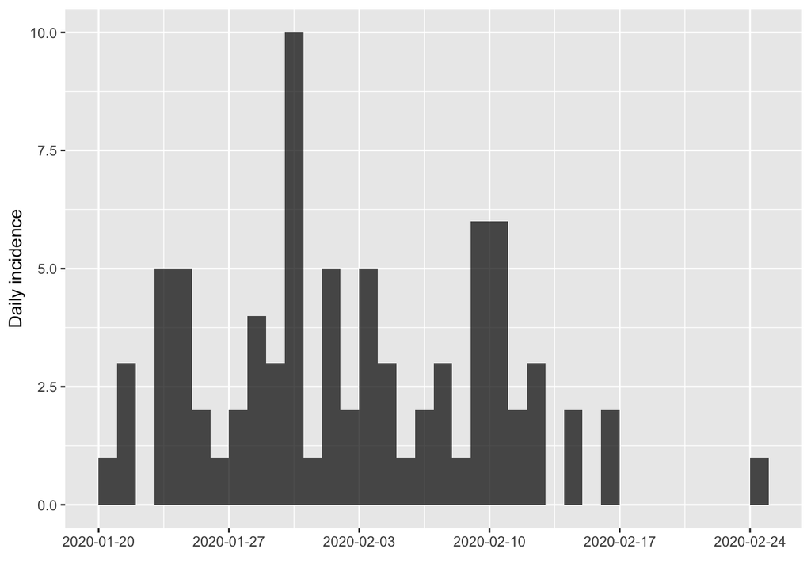

```r
plot(s.daily)
```

```r
t.daily <- incidence(t.sympt$symptom_onset,
                     interval = 1)
t.daily
```

```
## <incidence object>
## [125 cases from days 2020-01-14 to 2020-02-19]
##
## $counts: matrix with 37 rows and 1 columns
## $n: 125 cases in total
## $dates: 37 dates marking the left-side of bins
## $interval: 1 day
## $timespan: 37 days
## $cumulative: FALSE
```

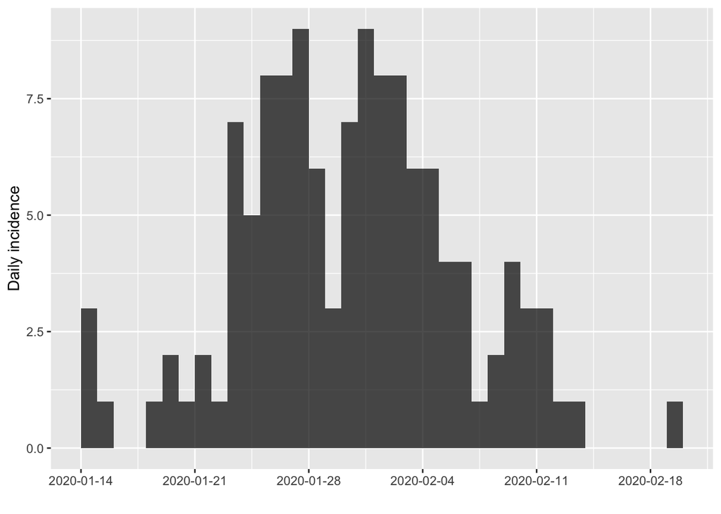

```r
plot(t.daily)
```

## Plot daily incidence curves grouped by source of infection, for both clusters

What happens when we look at the incidence plots for each source of infection?

```r
### 1. Singapore
s.grouped <- incidence(s.sympt$date_onset_symptoms,
                       interval = 1,
                       groups = s.sympt$presumed_reason_group)
s.grouped
```

```
## <incidence object>
## [81 cases from days 2020-01-20 to 2020-02-24]
## [8 groups: known relationship, wuhan travel, grace assembly of god, grand hyatt singapore, life church, seletar aerospace heights, yong thai hang, unknown]
##
## $counts: matrix with 36 rows and 8 columns
## $n: 81 cases in total
## $dates: 36 dates marking the left-side of bins
## $interval: 1 day
## $timespan: 36 days
## $cumulative: FALSE
```

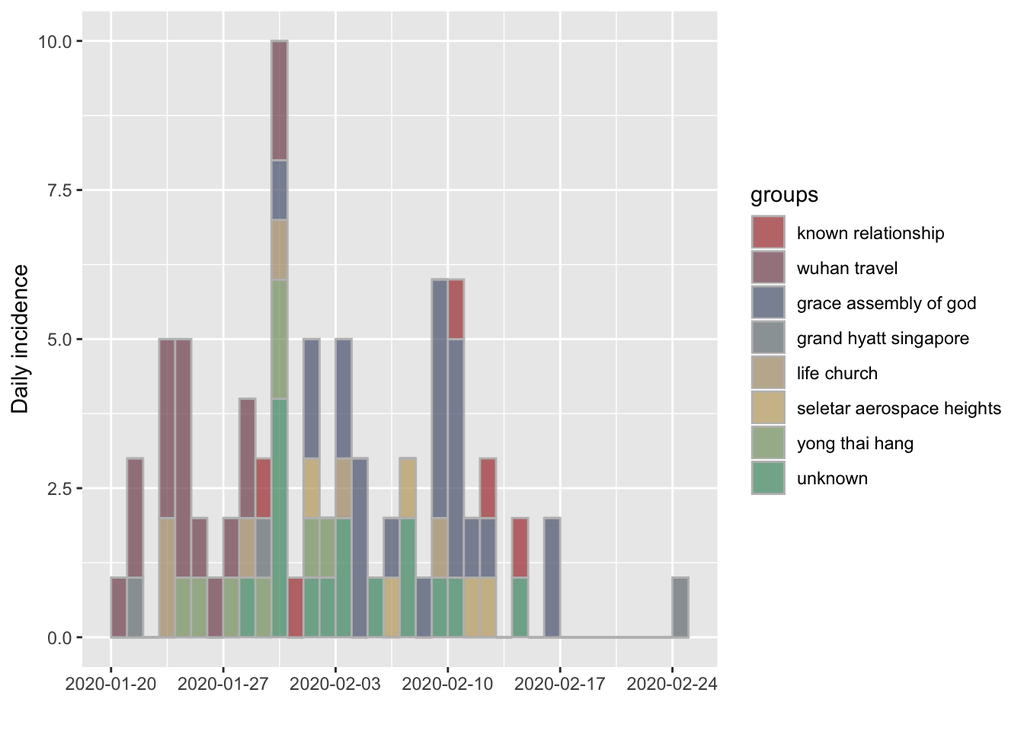

```r
plot(s.grouped,
    # stacked = TRUE,
     border = "grey")
```

```r
  #Hmmm, kinda hard to read with so many groups

s.grouped2 <- incidence(s.sympt$date_onset_symptoms,
                       interval = 1,
                       groups = s.sympt$presumed_reason_group2)
s.grouped2
```

```
## <incidence object>
## [81 cases from days 2020-01-20 to 2020-02-24]
## [4 groups: known relationship, wuhan travel, gatherings, unknown]
##
## $counts: matrix with 36 rows and 4 columns
## $n: 81 cases in total
## $dates: 36 dates marking the left-side of bins
## $interval: 1 day
## $timespan: 36 days
## $cumulative: FALSE
```

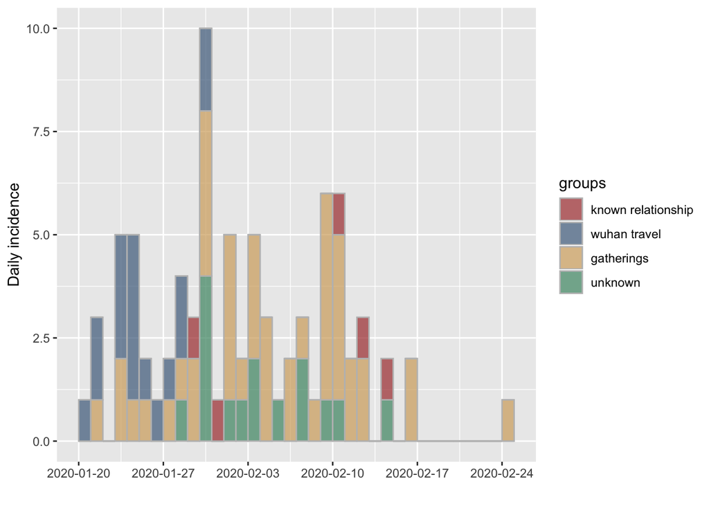

```r
plot(s.grouped2,
#     stacked = TRUE,
     border = "grey")
```

```r
  #Better!

#Hmmm...also kinda hard to read, need to fill each date with NAs for each group in
#ggplot(s.sympt, aes(x = date_onset_symptoms, fill = presumed_reason_group2)) +
#  geom_bar(position = "dodge") +
#  scale_fill_viridis_d()

### 2. Tianjin
t.grouped <- incidence(t.sympt$symptom_onset,
                       interval = 1,
                       groups = t.sympt$source_group)
t.grouped
```

```
## <incidence object>
## [125 cases from days 2020-01-14 to 2020-02-19]
## [6 groups: known relationship, wuhan origin, other China travel, location unclear travel, mall, unknown]
##
## $counts: matrix with 37 rows and 6 columns
## $n: 125 cases in total
## $dates: 37 dates marking the left-side of bins
## $interval: 1 day
## $timespan: 37 days
## $cumulative: FALSE
```

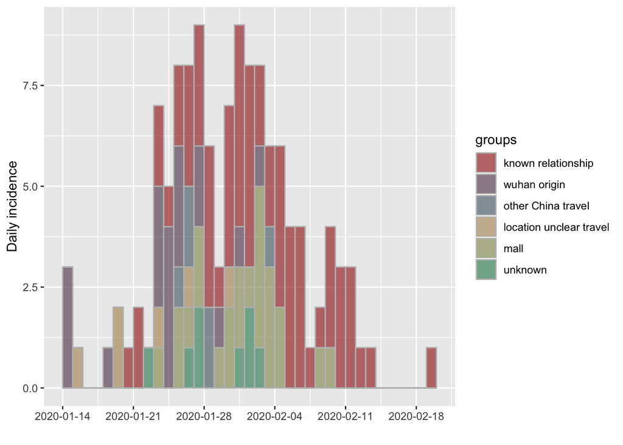

```r
plot(t.grouped,
    # stacked = TRUE,
     border = "grey")
```

## Predictions of incidence

We would like to know what the incidence might be in the future, which can be done by using two log-linear regressions of the incidence data (excluding zeros), where the first regression is fit to the growth phase of the epidemic and a second regression model is fit the decreasing phase of the epidemic. This can be done using the ‘incidence’ package, which will also automatically determine what is the date of the peak of the epidemic (and thus where to split the two regressions)

Another option would be to use a generalized additive model (GAM) to fit the curve of the data: would need to group by date, count # of cases, and I think put in zeros for the dates that had no cases. Could additionally do this by infection source groups.

```r
### 1. Singapore
s.fit <- fit_optim_split(s.daily)
s.fit
```

```
## $df
##        dates      mean.R2
## 1 2020-01-26 -0.134611171
## 2 2020-01-27 -0.075648336
## 3 2020-01-28 -0.033592218
## 4 2020-01-29 -0.026793908
## 5 2020-01-30  0.061916892
## 6 2020-01-31 -0.059341025
## 7 2020-02-01  0.016012924
## 8 2020-02-02 -0.027598690
## 9 2020-02-03  0.007849286
##
## $split
## [1] "2020-01-30"
##
## $fit
## <list of incidence_fit objects>
##
## attr(x, 'locations'): list of vectors with the locations of each incidence_fit object
##
## 'before'
## 'after'
##
## $model: regression of log-incidence over time
##
## $info: list containing the following items:
##   $r (daily growth rate):
##      before       after
##  0.09073334 -0.03712294
##
##   $r.conf (confidence interval):
##              2.5 %     97.5 %
## before -0.07118835 0.25265502
## after  -0.09417363 0.01992776
##
##   $doubling (doubling time in days):
##   before
## 7.639388
##
##   $doubling.conf (confidence interval):
##           2.5 %    97.5 %
## before 2.743453 -9.736807
##
##   $halving (halving time in days):
##    after
## 18.67167
##
##   $halving.conf (confidence interval):
##         2.5 %    97.5 %
## after 7.36031 -34.78299
##
##   $pred: data.frame of incidence predictions (27 rows, 6 columns)
##
## $plot
```

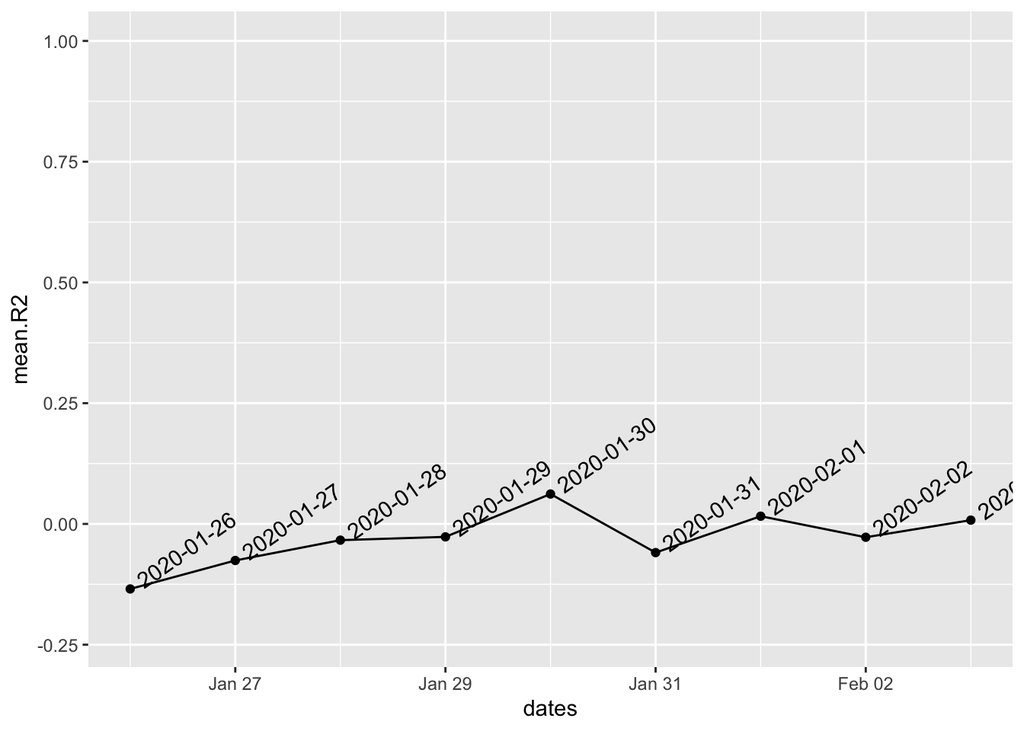

```r
s.fit$split # I belive this is the date where the two logistic regressions are split between 'growth' and 'decrease'
```

```
## [1] "2020-01-30"
```

```r
range(s.sympt$date_onset_symptoms)
```

```
## [1] "2020-01-20" "2020-02-24"
```

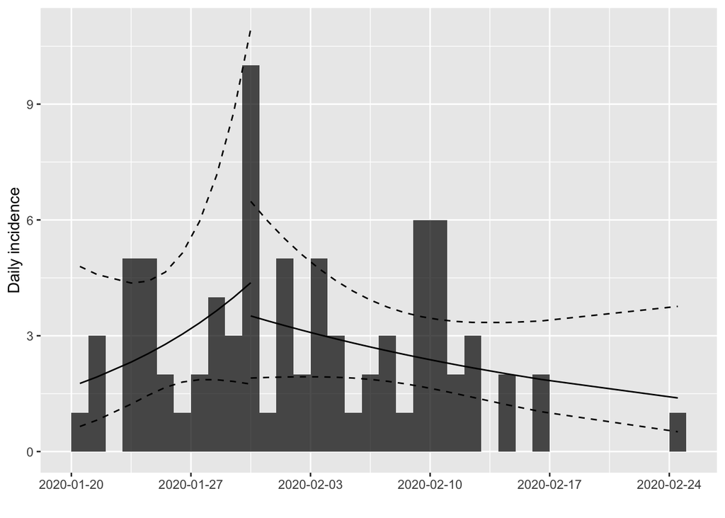

```r
plot(s.daily, fit = s.fit$fit)
```

```r
### 2. Tianjin
t.fit <- fit_optim_split(t.daily)
t.fit
```

```
## $df
##         dates   mean.R2
## 1  2020-01-22 0.1121236
## 2  2020-01-23 0.2459169
## 3  2020-01-24 0.3217863
## 4  2020-01-25 0.4306124
## 5  2020-01-26 0.4878898
## 6  2020-01-27 0.5286192
## 7  2020-01-28 0.5238827
## 8  2020-01-29 0.4752552
## 9  2020-01-30 0.5590968
## 10 2020-01-31 0.5791444
## 11 2020-02-01 0.5697951
##
## $split
## [1] "2020-01-31"
##
## $fit
## <list of incidence_fit objects>
##
## attr(x, 'locations'): list of vectors with the locations of each incidence_fit object
##
## 'before'
## 'after'
##
## $model: regression of log-incidence over time
##
## $info: list containing the following items:
##   $r (daily growth rate):
##     before      after
##  0.1206981 -0.1324890
##
##   $r.conf (confidence interval):
##              2.5 %      97.5 %
## before  0.05320853  0.18818760
## after  -0.18402441 -0.08095362
##
##   $doubling (doubling time in days):
##   before
## 5.742819
##
##   $doubling.conf (confidence interval):
##           2.5 %   97.5 %
## before 3.683278 13.02699
##
##   $halving (halving time in days):
##    after
## 5.231733
##
##   $halving.conf (confidence interval):
##          2.5 %   97.5 %
## after 3.766604 8.562275
##
##   $pred: data.frame of incidence predictions (31 rows, 6 columns)
##
## $plot
```

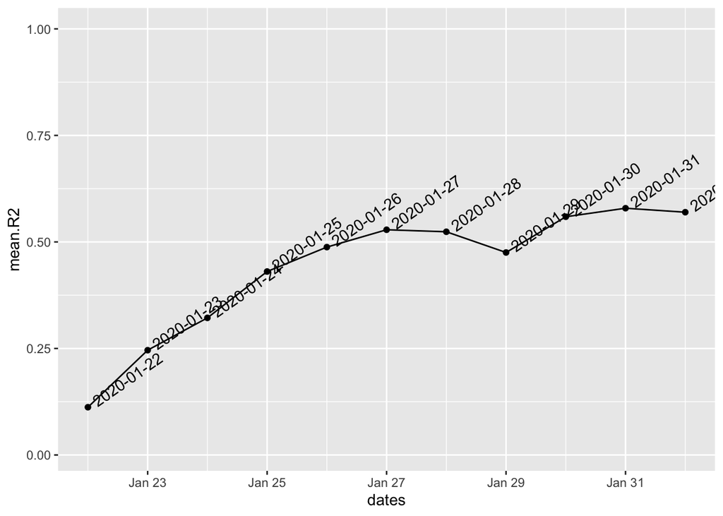

```r
t.fit$split
```

```
## [1] "2020-01-31"
```

```r
range(t.sympt$symptom_onset)
```

```
## [1] "2020-01-14" "2020-02-19"
```

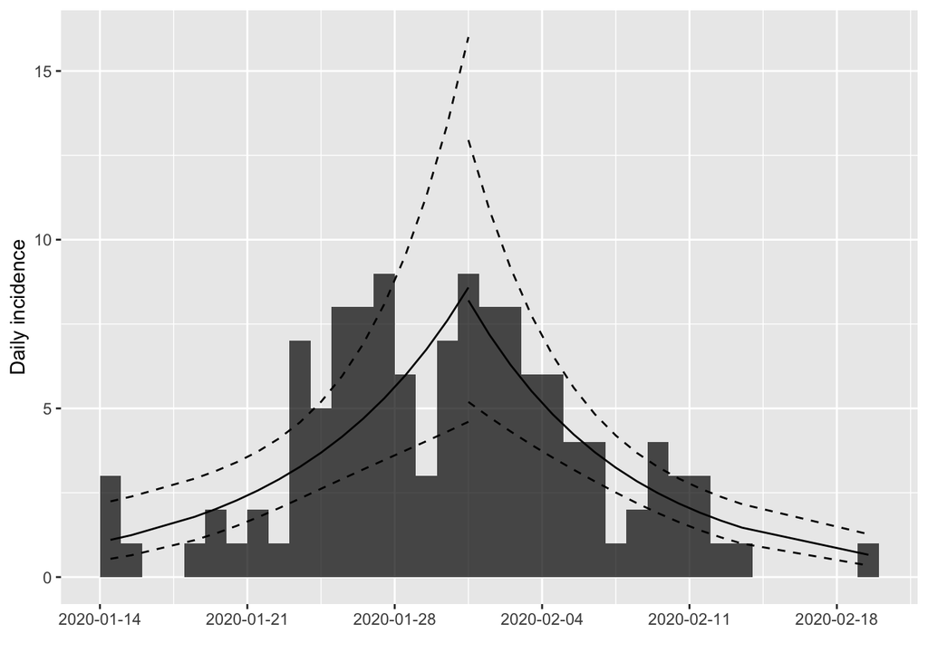

```r
plot(t.daily, fit = t.fit$fit)
```